# **Milestone 1**

## **Problem Definition**

**The context:** Why is this problem important to solve?  
**The objectives:** What is the intended goal?  
**The key questions:** What are the key questions that need to be answered?  
**The problem formulation:** What is it that we are trying to solve using data science?

## **Data Description:**

The Home Equity dataset (HMEQ) contains baseline and loan performance information for 5,960 recent home equity loans. The target (BAD) is a binary variable that indicates whether an applicant has ultimately defaulted or has been severely delinquent. This adverse outcome occurred in 1,189 cases (20 percent). 12 input variables were registered for each applicant.

- **BAD:** 1 = Client defaulted on loan, 0 = loan repaid
- **LOAN:** Amount of loan approved.
- **MORTDUE:** Amount due on the existing mortgage.
- **VALUE:** Current value of the property.
- **REASON:** Reason for the loan request. (HomeImp = home improvement, DebtCon= debt consolidation which means taking out a new loan to pay off other liabilities and consumer debts)
- **JOB:** The type of job that loan applicant has such as manager, self, etc.
- **YOJ:** Years at present job.
- **DEROG:** Number of major derogatory reports (which indicates a serious delinquency or late payments).
- **DELINQ:** Number of delinquent credit lines (a line of credit becomes delinquent when a borrower does not make the minimum required payments 30 to 60 days past the day on which the payments were due).
- **CLAGE:** Age of the oldest credit line in months.
- **NINQ:** Number of recent credit inquiries.
- **CLNO:** Number of existing credit lines.
- **DEBTINC:** Debt-to-income ratio (all your monthly debt payments divided by your gross monthly income. This number is one way lenders measure your ability to manage the monthly payments to repay the money you plan to borrow.

## **Important Notes**

- This notebook can be considered a guide to refer to while solving the problem. The evaluation will be as per the Rubric shared for each Milestone. Unlike previous courses, it does not follow the pattern of the graded questions in different sections. This notebook would give you a direction on what steps need to be taken in order to get a viable solution to the problem. Please note that this is just one way of doing this. There can be other 'creative' ways to solve the problem and we urge you to feel free and explore them as an 'optional' exercise.
- In the notebook, there are markdowns cells called - Observations and Insights. It is a good practice to provide observations and extract insights from the outputs.
- The naming convention for different variables can vary. Please consider the code provided in this notebook as a sample code.
- All the outputs in the notebook are just for reference and can be different if you follow a different approach.
- There are sections called **Think About It** in the notebook that will help you get a better understanding of the reasoning behind a particular technique/step. Interested learners can take alternative approaches if they want to explore different techniques.

### **Import the necessary libraries**

```python
import numpy as np
import pandas as pd
import matplotlib.pyplot as plt
import seaborn as sns
sns.set_theme()

from sklearn.model_selection import train_test_split

from sklearn.linear_model import LogisticRegression

from sklearn import metrics
from sklearn.metrics import confusion_matrix, classification_report,accuracy_score,precision_score,recall_score,f1_score

from sklearn import tree
from sklearn.tree import DecisionTreeClassifier

from sklearn.ensemble import BaggingClassifier
from sklearn.ensemble import RandomForestClassifier

import scipy.stats as stats

from sklearn.model_selection import GridSearchCV


import warnings
warnings.filterwarnings('ignore')
```

### **Read the dataset**

```python
hm=pd.read_csv("hmeq.csv")
```

```python
# Copying data to another variable to avoid any changes to original data
data=hm.copy()
```

### **Print the first and last 5 rows of the dataset**

```python
# Display first five rows
# Remove ___________ and complete the code

data.head()
```

|  | BAD | LOAN | MORTDUE | VALUE | REASON | JOB | YOJ | DEROG | DELINQ | CLAGE | NINQ | CLNO | DEBTINC |
| --- | --- | --- | --- | --- | --- | --- | --- | --- | --- | --- | --- | --- | --- |
| 0 | 1 | 1100 | 25860.0 | 39025.0 | HomeImp | Other | 10.5 | 0.0 | 0.0 | 94.366667 | 1.0 | 9.0 | NaN |
| 1 | 1 | 1300 | 70053.0 | 68400.0 | HomeImp | Other | 7.0 | 0.0 | 2.0 | 121.833333 | 0.0 | 14.0 | NaN |
| 2 | 1 | 1500 | 13500.0 | 16700.0 | HomeImp | Other | 4.0 | 0.0 | 0.0 | 149.466667 | 1.0 | 10.0 | NaN |
| 3 | 1 | 1500 | NaN | NaN | NaN | NaN | NaN | NaN | NaN | NaN | NaN | NaN | NaN |
| 4 | 0 | 1700 | 97800.0 | 112000.0 | HomeImp | Office | 3.0 | 0.0 | 0.0 | 93.333333 | 0.0 | 14.0 | NaN |

```python
# Display last 5 rows
# Remove ___________ and complete the code
data.tail()
```

|  | BAD | LOAN | MORTDUE | VALUE | REASON | JOB | YOJ | DEROG | DELINQ | CLAGE | NINQ | CLNO | DEBTINC |
| --- | --- | --- | --- | --- | --- | --- | --- | --- | --- | --- | --- | --- | --- |
| 5955 | 0 | 88900 | 57264.0 | 90185.0 | DebtCon | Other | 16.0 | 0.0 | 0.0 | 221.808718 | 0.0 | 16.0 | 36.112347 |
| 5956 | 0 | 89000 | 54576.0 | 92937.0 | DebtCon | Other | 16.0 | 0.0 | 0.0 | 208.692070 | 0.0 | 15.0 | 35.859971 |
| 5957 | 0 | 89200 | 54045.0 | 92924.0 | DebtCon | Other | 15.0 | 0.0 | 0.0 | 212.279697 | 0.0 | 15.0 | 35.556590 |
| 5958 | 0 | 89800 | 50370.0 | 91861.0 | DebtCon | Other | 14.0 | 0.0 | 0.0 | 213.892709 | 0.0 | 16.0 | 34.340882 |
| 5959 | 0 | 89900 | 48811.0 | 88934.0 | DebtCon | Other | 15.0 | 0.0 | 0.0 | 219.601002 | 0.0 | 16.0 | 34.571519 |

### **Understand the shape of the dataset**

```python
# Check the shape of the data
# Remove ___________ and complete the code

data.shape
```

```
(5960, 13)
```

**Insights:**

- The data set has **5,960 rows** and **13 columns**.
- There are missing values
- Some rows may be missing many data points

**Generating some Referential Lists for use later in the analysis:**

```python
#Generating a list of all column names
all_cols=data.columns.tolist()
```

```python
#Generating a list of numerical collumns
num_cols = data.select_dtypes('number').columns.tolist()
```

```python
#Creating a dictonary of all variable descriptions
variable_descriptions={
    'BAD' : '1 = Client defaulted on loan, 0 = loan repaid',
    'LOAN' : 'Amount of loan approved.',
    'MORTDUE' : 'Amount due on the existing mortgage.',
    'VALUE' : 'Current value of the property.',
    'REASON' : 'Reason for the loan request. (home improvement or debt consolidation)',
    'JOB' : 'The type of job that loan applicant has such as manager, self, etc.',
    'YOJ' : 'Years at present job.',
    'DEROG' : 'Number of major derogatory reports.',
    'DELINQ' : 'Number of delinquent credit lines.',
    'CLAGE' : 'Age of the oldest credit line in months.',
    'NINQ' : 'Number of recent credit inquiries.',
    'CLNO' : 'Number of existing credit lines.',
    'DEBTINC' : 'Debt-to-income ratio.'
}
```

### **Check the data types of the columns**

```python
# Check info of the data
# Remove ___________ and complete the code
data.info()
```

```
<class 'pandas.core.frame.DataFrame'>
RangeIndex: 5960 entries, 0 to 5959
Data columns (total 13 columns):
 #   Column   Non-Null Count  Dtype
---  ------   --------------  -----
 0   BAD      5960 non-null   int64
 1   LOAN     5960 non-null   int64
 2   MORTDUE  5442 non-null   float64
 3   VALUE    5848 non-null   float64
 4   REASON   5708 non-null   object
 5   JOB      5681 non-null   object
 6   YOJ      5445 non-null   float64
 7   DEROG    5252 non-null   float64
 8   DELINQ   5380 non-null   float64
 9   CLAGE    5652 non-null   float64
 10  NINQ     5450 non-null   float64
 11  CLNO     5738 non-null   float64
 12  DEBTINC  4693 non-null   float64
dtypes: float64(9), int64(2), object(2)
memory usage: 605.4+ KB
```

**Insights:**

- `REASON`, and `JOB` are categorical variables.
- `BAD` is of type **int**, but we know from the problem statement, this variable will also be treated as categorical.
- All other collumns are numeric in nature.

### **Check for missing values**

```python
# Analyse missing values - Hint: use isnull() function
# Remove ___________ and complete the code
data.isnull().sum()
```

```
BAD           0
LOAN          0
MORTDUE     518
VALUE       112
REASON      252
JOB         279
YOJ         515
DEROG       708
DELINQ      580
CLAGE       308
NINQ        510
CLNO        222
DEBTINC    1267
dtype: int64
```

```python
# Check the percentage of missing values in the each column.
# Hint: divide the result from the previous code by the number of rows in the dataset
# Remove ___________ and complete the code

(data.isnull().sum() / data.shape[0])*100
```

```
BAD         0.000000
LOAN        0.000000
MORTDUE     8.691275
VALUE       1.879195
REASON      4.228188
JOB         4.681208
YOJ         8.640940
DEROG      11.879195
DELINQ      9.731544
CLAGE       5.167785
NINQ        8.557047
CLNO        3.724832
DEBTINC    21.258389
dtype: float64
```

```python
#Checking the number of unique values in each collumn
data.nunique()
```

```
BAD           2
LOAN        540
MORTDUE    5053
VALUE      5381
REASON        2
JOB           6
YOJ          99
DEROG        11
DELINQ       14
CLAGE      5314
NINQ         16
CLNO         62
DEBTINC    4693
dtype: int64
```

**Insights**

- `BAD` and `LOAN` have no missing values
- All Other variables have at least 1 missing value
- `DEROG` and `DEBTINC` have a significant number of missing values (over 10% of the entries)

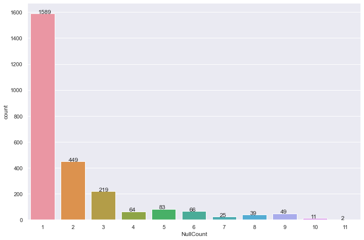

```python
null_counts=pd.DataFrame().assign(NullCount= data.isnull().sum(axis=1))
null_counts=null_counts[null_counts.NullCount!=0]

plt.figure(figsize=(12,8))
ax=sns.countplot(x=null_counts["NullCount"])
for p in ax.patches:
   ax.annotate('{:.0f}'.format(p.get_height()), (p.get_x()+0.25, p.get_height()+0.01))

plt.show()
```

```python
for i in range(1,12):
    ratio= null_counts['NullCount'].value_counts()[i]/len(data.index)
    print("Percentage of All Rows with", i ,"NaN Values:  ", "%2.2f%%" % (ratio*100), "  (", null_counts['NullCount'].value_counts()[i]," total rows)")
```

```
Percentage of All Rows with 1 NaN Values:   26.66%   ( 1589  total rows)
Percentage of All Rows with 2 NaN Values:   7.53%   ( 449  total rows)
Percentage of All Rows with 3 NaN Values:   3.67%   ( 219  total rows)
Percentage of All Rows with 4 NaN Values:   1.07%   ( 64  total rows)
Percentage of All Rows with 5 NaN Values:   1.39%   ( 83  total rows)
Percentage of All Rows with 6 NaN Values:   1.11%   ( 66  total rows)
Percentage of All Rows with 7 NaN Values:   0.42%   ( 25  total rows)
Percentage of All Rows with 8 NaN Values:   0.65%   ( 39  total rows)
Percentage of All Rows with 9 NaN Values:   0.82%   ( 49  total rows)
Percentage of All Rows with 10 NaN Values:   0.18%   ( 11  total rows)
Percentage of All Rows with 11 NaN Values:   0.03%   ( 2  total rows)
```

**Insights**

### **Think about it:**

- We found the total number of missing values and the percentage of missing values, which is better to consider?
  - *Percentage gives a better view of the effect the missing values may have on inferences made about the data*
- What can be the limit for % missing values in a column in order to avoid it and what are the challenges associated with filling them and avoiding them?
  - *Ideally we would like to have no missing data points. Realistically, given the size of the dataset and the variation of the unique values for each of the collumns, in most cases we would like to limit the percentage of missing value to be under 10%*

**We can convert the object type columns to categories**

`converting "objects" to "category" reduces the data space required to store the dataframe`

### **Convert the data types**

```python
cols = data.select_dtypes(['object']).columns.tolist()

#adding target variable to this list as this is an classification problem and the target variable is categorical

cols.append('BAD')
```

```python
cols
```

```
['REASON', 'JOB', 'BAD']
```

```python
# Changing the data type of object type column to category. hint use astype() function
# remove ___________ and complete the code

for i in cols:
    data[i] = data[i].astype('category')
```

```python
# Checking the info again and the datatype of different variable
# remove ___________ and complete the code

data.info()
```

```
<class 'pandas.core.frame.DataFrame'>
RangeIndex: 5960 entries, 0 to 5959
Data columns (total 13 columns):
 #   Column   Non-Null Count  Dtype
---  ------   --------------  -----
 0   BAD      5960 non-null   category
 1   LOAN     5960 non-null   int64
 2   MORTDUE  5442 non-null   float64
 3   VALUE    5848 non-null   float64
 4   REASON   5708 non-null   category
 5   JOB      5681 non-null   category
 6   YOJ      5445 non-null   float64
 7   DEROG    5252 non-null   float64
 8   DELINQ   5380 non-null   float64
 9   CLAGE    5652 non-null   float64
 10  NINQ     5450 non-null   float64
 11  CLNO     5738 non-null   float64
 12  DEBTINC  4693 non-null   float64
dtypes: category(3), float64(9), int64(1)
memory usage: 483.7 KB
```

### **Analyze Summary Statistics of the dataset**

```python
# Analyze the summary statistics for numerical variables
# Remove ___________ and complete the code

data.describe().T
```

|  | count | mean | std | min | 25% | 50% | 75% | max |
| --- | --- | --- | --- | --- | --- | --- | --- | --- |
| LOAN | 5960.0 | 18607.969799 | 11207.480417 | 1100.000000 | 11100.000000 | 16300.000000 | 23300.000000 | 89900.000000 |
| MORTDUE | 5442.0 | 73760.817200 | 44457.609458 | 2063.000000 | 46276.000000 | 65019.000000 | 91488.000000 | 399550.000000 |
| VALUE | 5848.0 | 101776.048741 | 57385.775334 | 8000.000000 | 66075.500000 | 89235.500000 | 119824.250000 | 855909.000000 |
| YOJ | 5445.0 | 8.922268 | 7.573982 | 0.000000 | 3.000000 | 7.000000 | 13.000000 | 41.000000 |
| DEROG | 5252.0 | 0.254570 | 0.846047 | 0.000000 | 0.000000 | 0.000000 | 0.000000 | 10.000000 |
| DELINQ | 5380.0 | 0.449442 | 1.127266 | 0.000000 | 0.000000 | 0.000000 | 0.000000 | 15.000000 |
| CLAGE | 5652.0 | 179.766275 | 85.810092 | 0.000000 | 115.116702 | 173.466667 | 231.562278 | 1168.233561 |
| NINQ | 5450.0 | 1.186055 | 1.728675 | 0.000000 | 0.000000 | 1.000000 | 2.000000 | 17.000000 |
| CLNO | 5738.0 | 21.296096 | 10.138933 | 0.000000 | 15.000000 | 20.000000 | 26.000000 | 71.000000 |
| DEBTINC | 4693.0 | 33.779915 | 8.601746 | 0.524499 | 29.140031 | 34.818262 | 39.003141 | 203.312149 |

**Insights**

- `Derog` and `Delinq` have the least variation in its summary statistics but a high max value which may indicate that likelihood of these occurances is minimal and that the majority of borrows have 0 derogatory reports and delinquent credit lines

```python
# Check summary for categorical data - Hint: inside describe function you can use the argument include=['category']
# Remove ___________ and complete the code

data.describe(include = ['category']).T
```

|  | count | unique | top | freq |
| --- | --- | --- | --- | --- |
| BAD | 5960 | 2 | 0 | 4771 |
| REASON | 5708 | 2 | DebtCon | 3928 |
| JOB | 5681 | 6 | Other | 2388 |

**Insights**

- The majority of borrowers repaid their loan
- The majority of borrowers did so to consolidate debt
- The majority of borrowers had a job title of "other"

**Let's look at the unique values in all the categorical variables**

```python
# Checking the count of unique values in each categorical column
# Remove ___________ and complete the code

cols_cat= data.select_dtypes(['category'])

for i in cols_cat.columns:
    print('Unique values in',i, 'are :')
    print(cols_cat[i].value_counts())
    print('*'*40)
```

```
Unique values in BAD are :
0    4771
1    1189
Name: BAD, dtype: int64
Unique values in REASON are :
DebtCon    3928
HomeImp    1780
Name: REASON, dtype: int64
Unique values in JOB are :
Other      2388
ProfExe    1276
Office      948
Mgr         767
Self        193
Sales       109
Name: JOB, dtype: int64
```

**Insights**

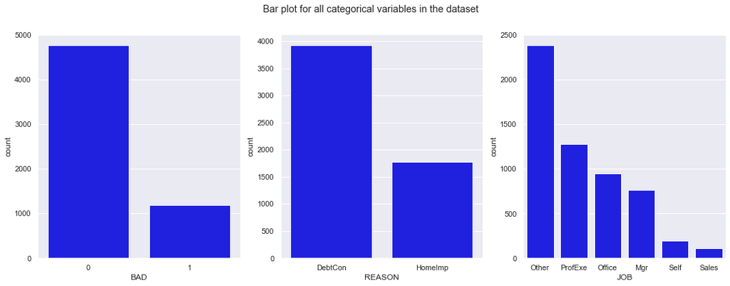

```python
fig, axes = plt.subplots(1, 3, figsize = (18, 6))

fig.suptitle('Bar plot for all categorical variables in the dataset')

sns.countplot(ax = axes[0], x = 'BAD', data = data, color = 'blue',
              order = data['BAD'].value_counts().index);

sns.countplot(ax = axes[1], x = 'REASON', data = data, color = 'blue',
              order = data['REASON'].value_counts().index);

sns.countplot(ax = axes[2], x = 'JOB', data = data, color = 'blue',
              order = data['JOB'].value_counts().index);
```

### **Think about it**

- The results above gave the absolute count of unique values in each categorical column. Are absolute values a good measure?
- If not, what else can be used? Try implementing that.

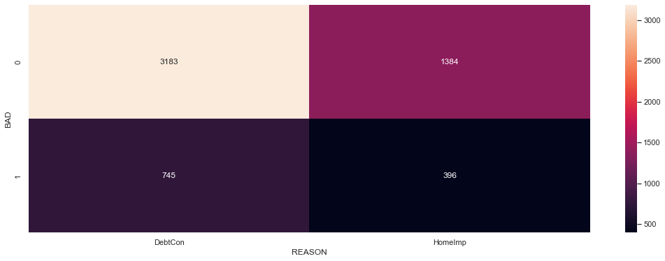

```python
fig = plt.figure(figsize = (18, 6))

sns.heatmap(pd.crosstab(index = data['BAD'], columns = data['REASON']), annot = True, fmt = 'g')
```

**Insights**

- A greater ratio of borrows that borrowed for home improvement (~23%) defaulted on their loan than those that consolidated debt (~19%)

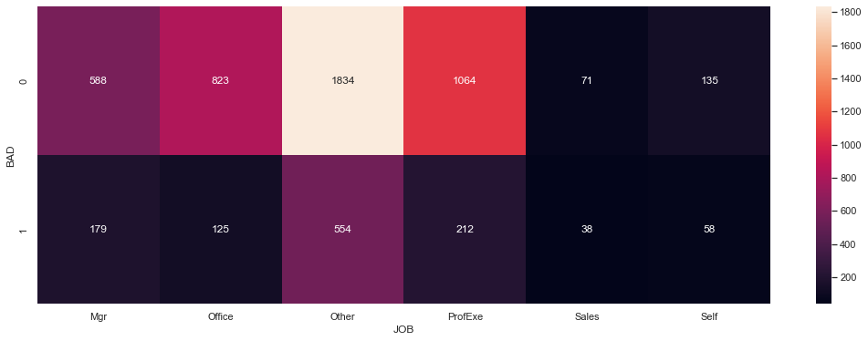

```python
fig = plt.figure(figsize = (18, 6))

sns.heatmap(pd.crosstab(index = data['BAD'], columns = data['JOB']), annot = True, fmt = 'g')
```

**Insights**

- Borrowers who had job types of `office` and `profexe` had the lowest ratio of defaulting on a loan (*approximately 13% and 17%, respectively*) indicating they are the most likely to repay their loan
- Borrowers who had job types of `sales` and `self` had the highest ratio of defaulting on a loan (*appoximately 35% and 30%, respectively*) indicating they are the most likely to default on their loan
- Both `Mgr` and `other` job types had apprimately 23% of borrowers who defaulted on their loan.

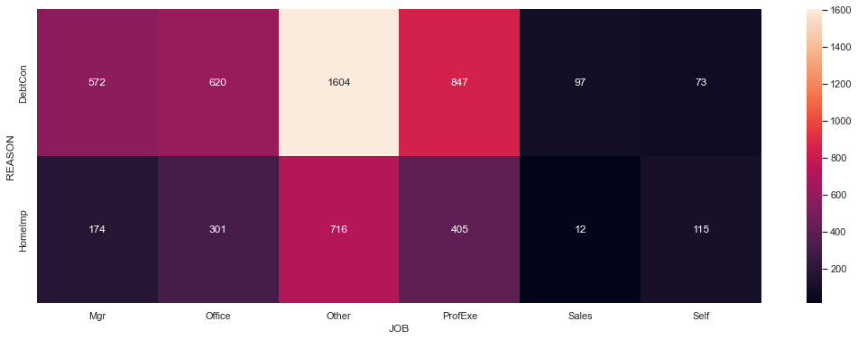

```python
fig = plt.figure(figsize = (18, 6))

sns.heatmap(pd.crosstab(index = data['REASON'], columns = data['JOB']), annot = True, fmt = 'g')
```

**Insights**

## **Exploratory Data Analysis (EDA) and Visualization**

## **Univariate Analysis**

Univariate analysis is used to explore each variable in a data set, separately. It looks at the range of values, as well as the central tendency of the values. It can be done for both numerical and categorical variables

### **1. Univariate Analysis - Numerical Data**

Histograms and box plots help to visualize and describe numerical data. We use box plot and histogram to analyze the numerical columns.

```python
# While doing uni-variate analysis of numerical variables we want to study their central tendency and dispersion.
# Let us write a function that will help us create boxplot and histogram for any input numerical variable.
# This function takes the numerical column as the input and return the boxplots and histograms for the variable.
# Let us see if this help us write faster and cleaner code.
def histogram_boxplot(feature, figsize=(15,10), bins = None):
    """ Boxplot and histogram combined
    feature: 1-d feature array
    figsize: size of fig (default (9,8))
    bins: number of bins (default None / auto)
    """
    f2, (ax_box2, ax_hist2) = plt.subplots(nrows = 2, # Number of rows of the subplot grid= 2
                                           sharex = True, # x-axis will be shared among all subplots
                                           gridspec_kw = {"height_ratios": (.25, .75)},
                                           figsize = figsize
                                           ) # creating the 2 subplots
    sns.boxplot(feature, ax=ax_box2, showmeans=True, color='violet') # boxplot will be created and a star will indicate the mean value of the column
    sns.distplot(feature, kde=F, ax=ax_hist2, bins=bins,palette="winter") if bins else sns.distplot(feature, kde=False, ax=ax_hist2) # For histogram
    ax_hist2.axvline(np.mean(feature), color='green', linestyle='--') # Add mean to the histogram
    ax_hist2.axvline(np.median(feature), color='black', linestyle='-') # Add median to the histogram
```

#### Using the above function, let's first analyze the Histogram and Boxplot for LOAN

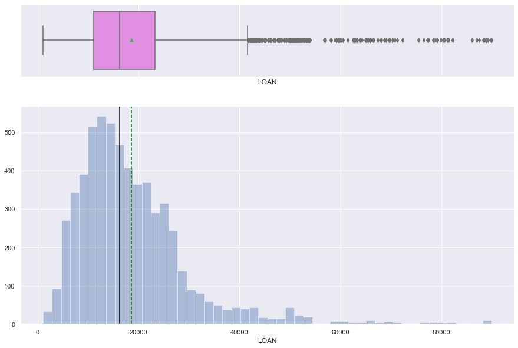

```python
# Build the histogram boxplot for Loan
histogram_boxplot(data['LOAN'])
```

**Insights**

- The distribution of `Loans` is skewed right with a relatively normal distribution
- There are many outliers, but appear to be evenly spaced and may not need to be treated with 1.5*IQR

#### **Note:** As done above, analyze Histogram and Boxplot for other variables

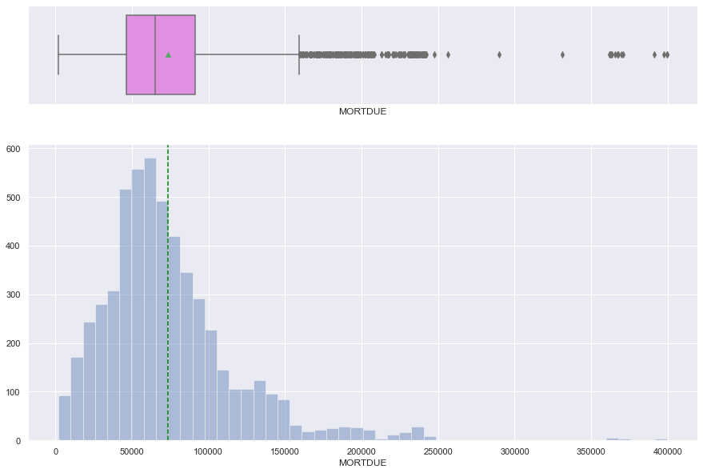

```python
# Build the histogram boxplot for Loan
histogram_boxplot(data['MORTDUE'])
```

**Insights**

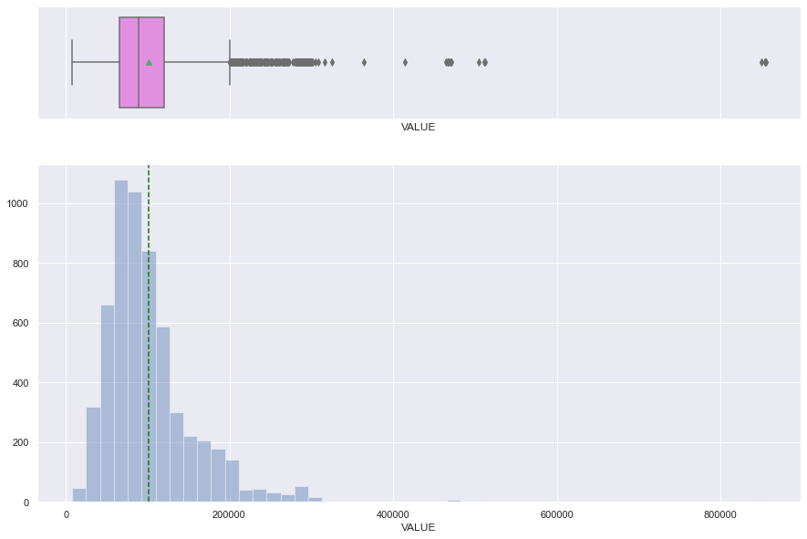

```python
# Build the histogram boxplot for Loan
histogram_boxplot(data['VALUE'])
```

**Insights**

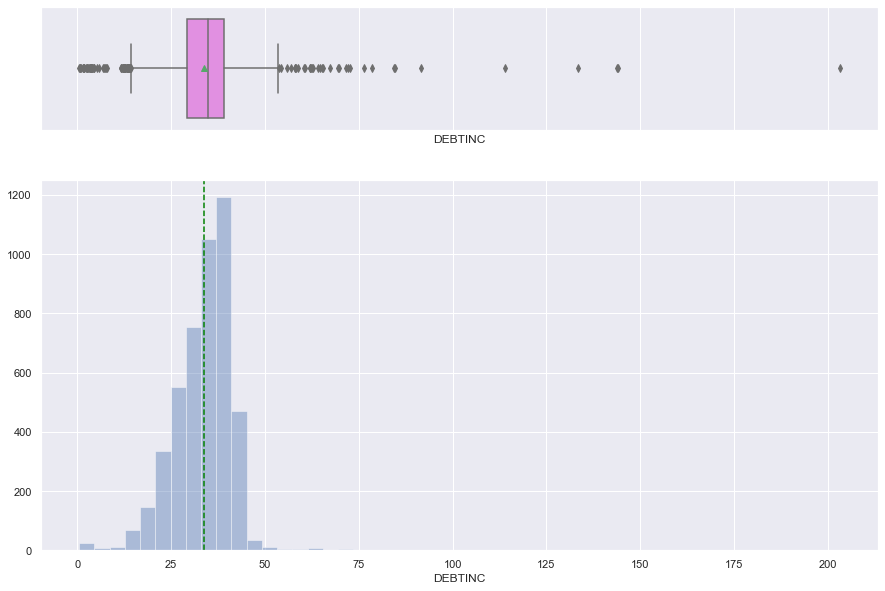

```python
# Build the histogram boxplot for Loan
histogram_boxplot(data['DEBTINC'])
```

**Insights**

- The distribution of `DEBTINC` is normally distibuted
- There are some outliers in the data with many being significantly greater, or far from the the majority, this should be treated by trimming them to 1.5*IQR

```
YOJ :
Years at present job.
Skew : 0.99
```

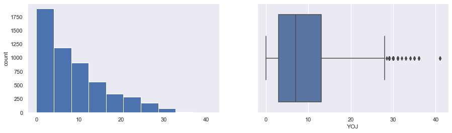

```
DEROG :
Number of major derogatory reports.
Skew : 5.32
```

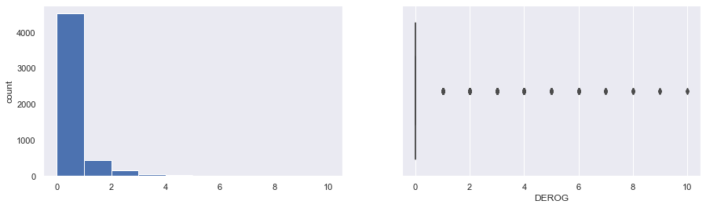

```
DELINQ :
Number of delinquent credit lines.
Skew : 4.02
```

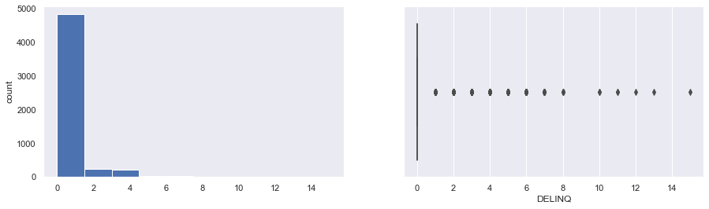

```
CLAGE :
Age of the oldest credit line in months.
Skew : 1.34
```

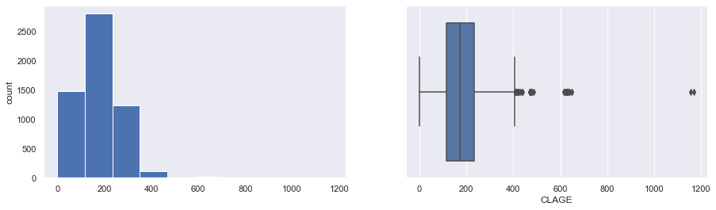

```
NINQ :
Number of recent credit inquiries.
Skew : 2.62
```

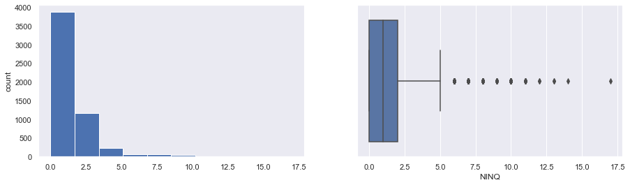

```
CLNO :
Number of existing credit lines.
Skew : 0.78
```

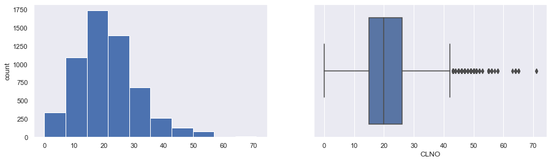

```python
for col in ['YOJ','DEROG','DELINQ','CLAGE','NINQ','CLNO']:
    print(col,":")
    print("\033[92m{}\033[00m".format(variable_descriptions[col]))

    print('Skew :',round(data[col].skew(), 2))

    plt.figure(figsize = (15, 4))

    plt.subplot(1, 2, 1)

    data[col].hist(bins = 10, grid = False)

    plt.ylabel('count')

    plt.subplot(1, 2, 2)

    sns.boxplot(x = data[col])

    plt.show()
```

### **2. Univariate Analysis - Categorical Data**

```python
# Function to create barplots that indicate percentage for each category.

def perc_on_bar(plot, feature):
    '''
    plot
    feature: categorical feature
    the function won't work if a column is passed in hue parameter
    '''

    total = len(feature) # length of the column
    for p in ax.patches:
        percentage = '{:.1f}%'.format(100 * p.get_height()/total) # percentage of each class of the category
        x = p.get_x() + p.get_width() / 2 - 0.05 # width of the plot
        y = p.get_y() + p.get_height()           # height of the plot
        ax.annotate(percentage, (x, y), size = 12) # annotate the percentage

    plt.show() # show the plot
```

#### Analyze Barplot for DELINQ

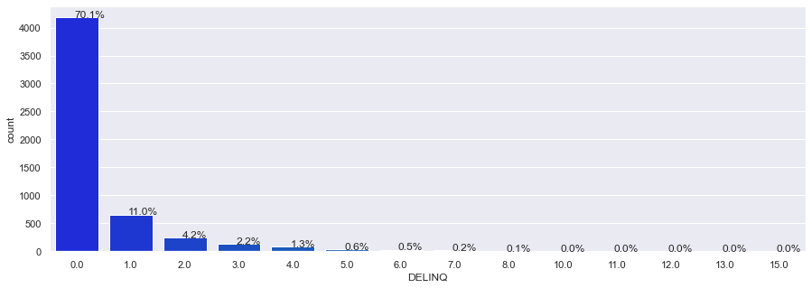

```python
#Build barplot for DELINQ

plt.figure(figsize=(15,5))
ax = sns.countplot(data["DELINQ"],palette='winter')
perc_on_bar(ax,data["DELINQ"])
```

**Insights**

- Most borrowers did not have delinquent credit lines

## **Bivariate Analysis**

### **Bivariate Analysis: Continuous and Categorical Variables**

#### Analyze BAD vs Loan

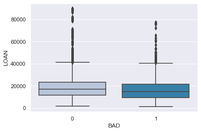

```python
sns.boxplot(data["BAD"],data['LOAN'],palette="PuBu")
```

**Insights**

- The distribution of repaid loan amount ranges and means are slightly higher than those that defaulted insinuating that larger loans are more likely to be repaid

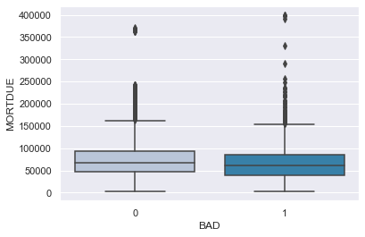

```python
sns.boxplot(data["BAD"],data['MORTDUE'],palette="PuBu")
```

**Insights**

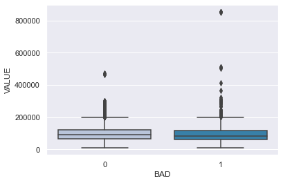

```python
sns.boxplot(data["BAD"],data['VALUE'],palette="PuBu")
```

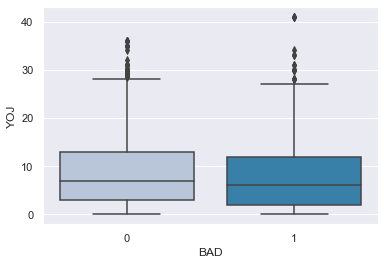

```python
sns.boxplot(data["BAD"],data['YOJ'],palette="PuBu")
```

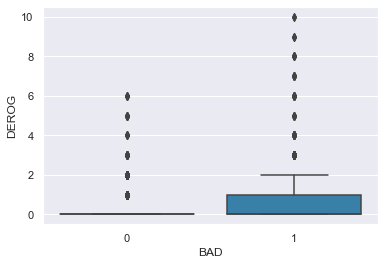

```python
sns.boxplot(data["BAD"],data['DEROG'],palette="PuBu")
```

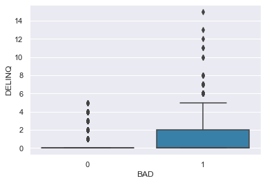

```python
sns.boxplot(data["BAD"],data['DELINQ'],palette="PuBu")
```

**Insights**

- 6 or more Delinquent Credit lines never repaid their loans

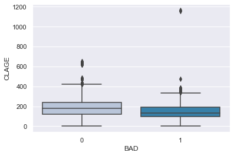

```python
sns.boxplot(data["BAD"],data['CLAGE'],palette="PuBu")
```

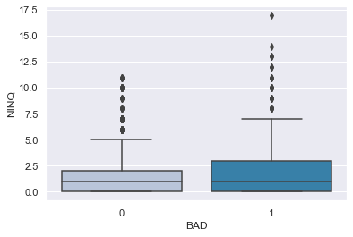

```python
sns.boxplot(data["BAD"],data['NINQ'],palette="PuBu")
```

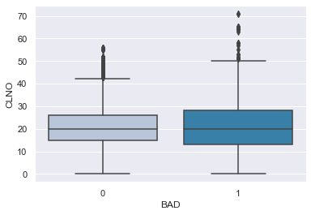

```python
sns.boxplot(data["BAD"],data['CLNO'],palette="PuBu")
```

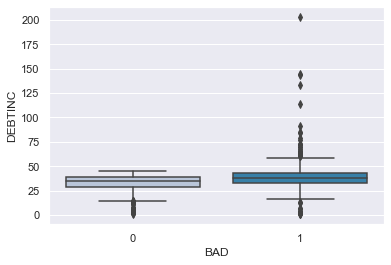

```python
sns.boxplot(data["BAD"],data['DEBTINC'],palette="PuBu")
```

**Insights**

- Borrowers with a higher depbt to income ratio appear to be more likely to default on their loan

### **Bivariate Analysis: Two Continuous Variables**

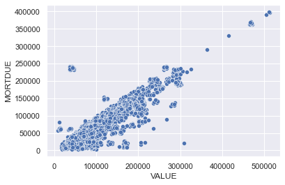

```python
sns.scatterplot(data["VALUE"],data['MORTDUE'],palette="PuBu")
```

**Insights:**

- There is a strong positive correlation with the value of the property and the amount due on the existing mortgage

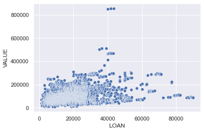

```python
sns.scatterplot(data["LOAN"],data['VALUE'],palette="PuBu")
```

**Insights**

- There does not appear to be a significant correlation with the loan amount and the value of the property

#### **Note:** As shown above, perform Bivariate Analysis on different pairs of continuous variables

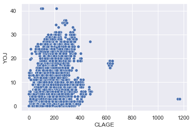

```python
sns.scatterplot(data["CLAGE"],data['YOJ'],palette="PuBu")
```

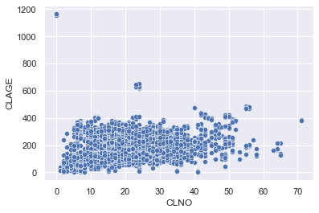

```python
sns.scatterplot(data["CLNO"],data['CLAGE'],palette="PuBu")
```

### **Bivariate Analysis: BAD vs Categorical Variables**

**The stacked bar chart (aka stacked bar graph)** extends the standard bar chart from looking at numeric values across one categorical variable to two.

```python
### Function to plot stacked bar charts for categorical columns

def stacked_plot(x):
    sns.set(palette='nipy_spectral')
    tab1 = pd.crosstab(x,data['BAD'],margins=True)
    print(tab1)
    print('-'*120)
    tab = pd.crosstab(x,data['BAD'],normalize='index')
    tab.plot(kind='bar',stacked=True,figsize=(10,5))
    plt.legend(loc='lower left', frameon=False)
    plt.legend(loc="upper left", bbox_to_anchor=(1,1))
    plt.show()
```

```
BAD         0     1   All
REASON
DebtCon  3183   745  3928
HomeImp  1384   396  1780
All      4567  1141  5708
------------------------------------------------------------------------------------------------------------------------
```

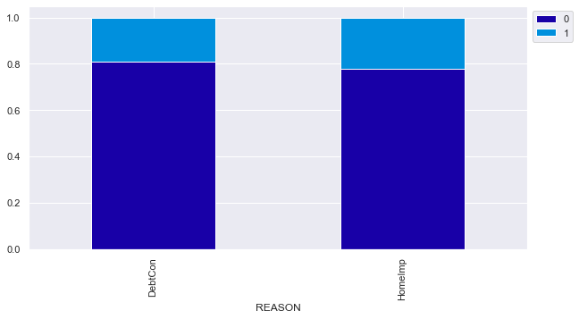

```python
# Plot stacked bar plot for BAD and REASON
stacked_plot(data['REASON'])
```

**Insights**

- Home improvement loans are more likely to default

```
BAD         0     1   All
JOB
Mgr       588   179   767
Office    823   125   948
Other    1834   554  2388
ProfExe  1064   212  1276
Sales      71    38   109
Self      135    58   193
All      4515  1166  5681
------------------------------------------------------------------------------------------------------------------------
```

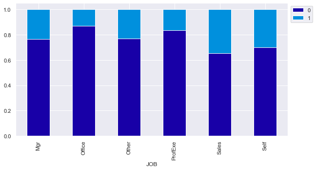

```python
# Plot stacked bar plot for BAD and REASON
stacked_plot(data['JOB'])
```

#### **Note:** As shown above, perform Bivariate Analysis on different pairs of Categorical vs BAD

**Insights**

- `Sales` and `Self` Are the most likely to default on a loan
- `Office` is the least likely to default on a loan